# in beta

```python
!date
```

```
Sun 25 Jul 2021 06:39:03 PM EDT
```

```python
print('hello happy world')
```

```
hello happy world
```

```python
import numpy as np
import keras
```

```python
from keras.datasets import mnist
```

```
7
```

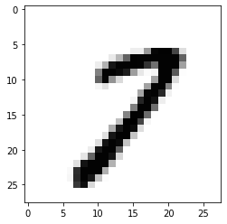

```python
import matplotlib.pyplot as plt
%matplotlib inline
image_index = 44413
image_index = 44417
print(ytrn[image_index])
plt.imshow(xtrn[image_index], cmap='Greys')
```

Boy that was cool huh. That number comes from the mnist data set. I don't know what mnnist stands for. I'm 68% sure the *n* stands for numbers. Don't quote me on that.

I won't be working with MNIST today but it's a dataset for training programs how to interpret handwritten digits.

Pretty Neat Shtuff.

That's as far as I got into a programming book about Deep Learning today. The funny thing is that this piece of code just came from some random tutorial I looked up to see how to *see* the data in this MNIST data set. The tutorial was about building a convulational neural network. Uh huh. Yup.

That's how it goes sometimes. The deep learning book is cool but it's too much code to post today about something I know absolutely nothing about. And to write about it nonetheless. pffft.

What I realized when I opened the deep learning book was mostly that I don't know the basic stuff. There are some cool things I can do at the moment with machine learning but def not on my own, obviously spent with hours of google, youtube, and a scary amount of decaf coffee.

what i like sleep okay.

in the future I may write a few blocks of text explaining these things. again. for my benefit. they'll be available for your entertainment.

what's going to happen next is going to be a complete 180.

# SQL

I realized I have an incredible blindspot. I don't really know how to use SQL in a daily industrial strength sense. I've done projects with it and gone through the process of setting up ways to do things with it and databases and such, but I don't do it on the daily for my daily practice.

Daily daily daily.

At the moment I can probably read my way through some 50 to 100 liners queries and *sort* of know what's going on, it would probably take me like, a week to write one :P.

At my last job, I didn't have access to the SQL tools. At my current position, it appears that the more SQL I know, the more SQL related problems I'll get to solve.

duh right

but if you're going to solve problems all day you might as well try to set it up in a way that allows you to solve the problems that feel challenging and make you sharper.

so without further ado, to the main event. i know everyone comes here for the tutorials. so here we go. your first command in sql.

```
select * from some_table
```

```
what's it do?
```

pull's all the records from that table named `some_table`

```
when can I do this?
```

don't EVER do it before asking someone you can do it on a database

that's how powerful it is. also like...if you have 1,000,000+ rows and you're working on a client's remote machine that's probably like a dusty computer in a closet somewhere on not great internet on site and you make that call...well...just don't.

i don't know from experience.

anyway. that's it. next time I'll probably have more things about the sql things I'm learning or write other blogs about deep learning.

until then, that's my one percent.

[tutorial i copy pasta-ed code from](https://towardsdatascience.com/image-classification-in-10-minutes-with-mnist-dataset-54c35b77a38d) [book that i mentioned was about deep learning](https://nostarch.com/practical-deep-learning-python)